# Applied Statistics with R Report

Michal Jachman

# 1. Introduction and dataset description

This data was collected with an on-line version of the Depression Anxiety Stress Scales (DASS), see http://www2.psy.unsw.edu.au/dass/

This data was collected in the years: 2017 - 2019. The data-set contains 39775 rows of 172 variables.

The survey was open to anyone and people were motivated to take it to get personalized results. The main survey consisted of 42 questions concerning anxiety, depression and stress. Each item was presented one at a time in a random order for each new participant along with a 4 point rating scale asking the user to indicate how often that had been true of them in the past week where

- 1 = Did not apply to me at all
- 2 = Applied to me to some degree, or some of the time
- 3 = Applied to me to a considerable degree, or a good part of the time
- 4 = Applied to me very much, or most of the time At the end of the test they also were given the option to complete a short research survey.

The main DASS survey was followed by a generic demographics survey with many different questions including age, education, family size, etc.

Another important element of the survey a ten item personality inventory (TIPI) survey. The survey measures 5 personality traits:

- Extraversion
- Agreeableness
- Consientiousness
- Emotional Stability
- Openness to Experiences

My hypothesis is that people with low levels of emotional stability tend to score highest on the DASS test.

## 1.1. Data preparation

The following items were presented as a check-list and subjects were instructed “In the grid below, check all the words whose definitions you are sure you know”: Three items on the list were not real words so I have excluded the results that claimed to know them from the data-set. The other factor I took into account was age. Some of the responses showed age that was impossible for a human being. I also removed the rows with values TIPI=0 and education=0 since the minimum value allowed by the survey was 1.

```r
library(readr)
library(ggplot2)
library(colr)
data <- read_delim("C:/Users/Administrator/Desktop/DASS/data.csv",delim = "\t", escape_double = FALSE, trim_ws = TRUE)

d <- subset(data, (VCL6 + VCL9 + VCL12)==0 & age < 115 & TIPI1>0 & TIPI2>0 & TIPI3>0 & TIPI3>0 & TIPI4>0 & TIPI5>0 & TIPI6>0 & TIPI7>0 & TIPI8>0 & TIPI9>0 & TIPI10>0 & education!=0)
```

# 2. Score analysis

For data analysis I summed the columns labeled Q1A-Q42A which contained responses to DASS questions. Each question has 1-4 scale. This gives a minimum possible score of 42 and maximum possible score of 168. The more points the more stressed/depressed/anxious the person is.

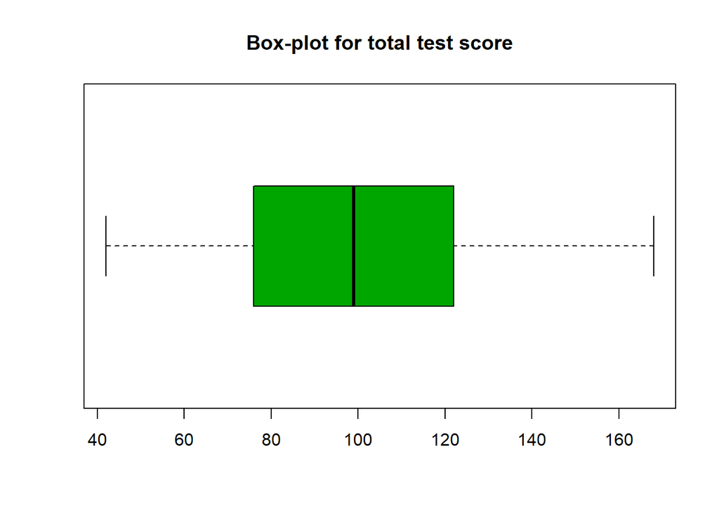

```r
score=rowSums(cgrep(d,"Q[0-9]?[0-9]A"))
b=boxplot(score, main = "Box-plot for total test score",horizontal = TRUE,col = terrain.colors(2))
```

```r
boxplot.stats(score,coef = 1.5, do.conf = TRUE, do.out = TRUE)
```

```
## $stats
## [1]  42  76  99 122 168
##
## $n
## [1] 32870
##
## $conf
## [1] 98.59912 99.40088
##
## $out
## numeric(0)
```

Box-plot stats:

- Minimum:42
- Maximum: 168
- Median: 99
- Q1: 76
- Q3: 122
- No outliers

## 2.1. Education-score analysis

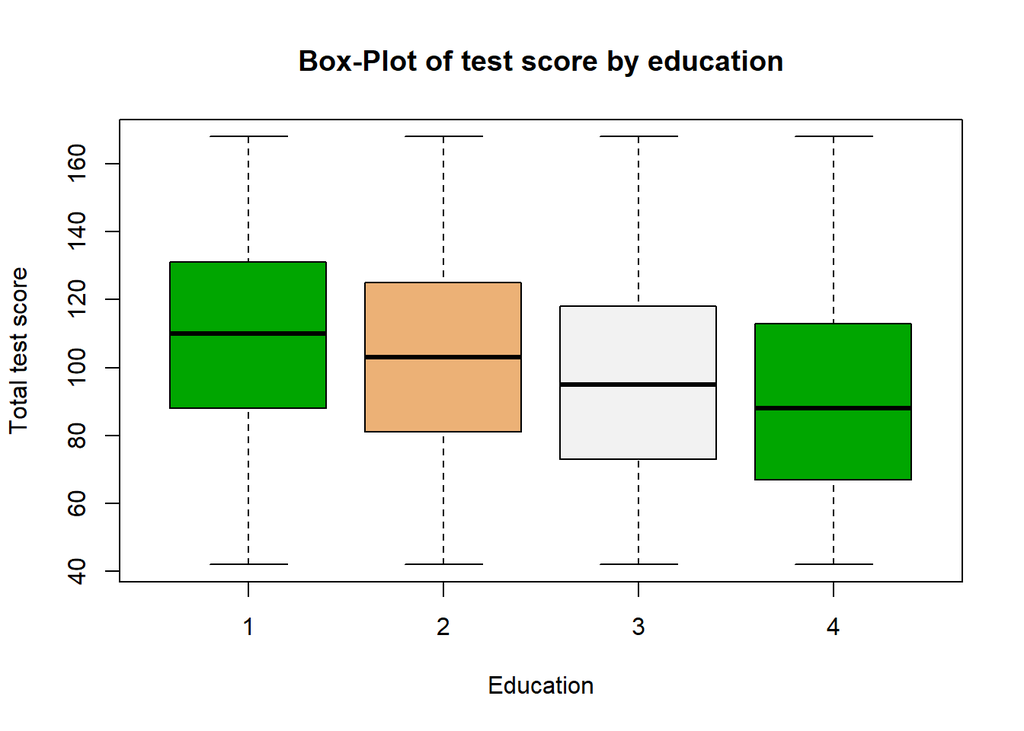

```r
boxplot(score ~ d$education, main = "Box-Plot of test score by education",
        col = terrain.colors(3), xlab = "Education", ylab = "Total test score")
```

“How much education have you completed?”, 1=Less than high school, 2=High school, 3=University degree, 4=Graduate degree

Judging from the box-plot I conclude that people with higher levels of education tend to have lower depression/anxiety/stress levels.

## 2.2. Score distribution

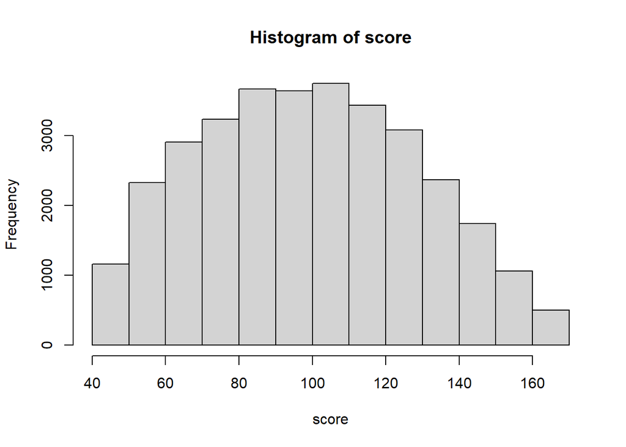

```r
hist(score)
```

# 3. Correlation index “r”

I checked the correlation index for multiple quantitative variables.

By applying the formula found on https://gosling.psy.utexas.edu/scales-weve-developed/ten-item-personality-measure-tipi/ I measured TIPI scores for each of the 5 personality traits.

I also measured correlation between age and family size in relation to overall test score.

```r
cor((d$TIPI1+(8-d$TIPI6))/2,score) #extraversion
```

```
## [1] -0.2411777
```

```r
cor(((8-d$TIPI2)+d$TIPI7)/2,score) #agreeableness
```

```
## [1] -0.1735432
```

```r
cor((d$TIPI3+(8-d$TIPI8))/2,score) #conscientiousness
```

```
## [1] -0.2845998
```

```r
cor(((8-d$TIPI4)+d$TIPI9)/2,score) # emotional stability
```

```
## [1] -0.62832
```

```r
cor((d$TIPI5+(8-d$TIPI10))/2,score) # openness to experiences
```

```
## [1] -0.2428455
```

```r
cor(d$age,score) #age
```

```
## [1] -0.1928776
```

```r
cor(d$familysize,score) #familysize
```

```
## [1] -0.02423785
```

```r
emo=((8-d$TIPI4)+d$TIPI9)/2
```

All the variables show low correlation index in relation to the overall test score except for emotional stability. The correlation index *r* is -0.628 which is considered a medium-high correlation. The less emotionally stable a person is the higher they score on the DASS survey. This makes a lot of sense.

## 3.2. Scatter plot for overall score in relation to emotional stability

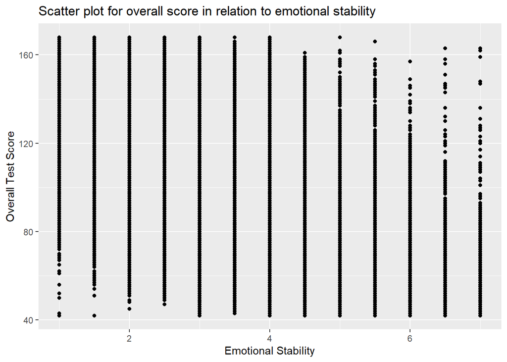

```r
ggplot(data=d)+
  geom_point(mapping=aes(emo,score))+
  xlab("Emotional Stability") + ylab("Overall Test Score")+
  ggtitle("Scatter plot for overall score in relation to emotional stability")
```

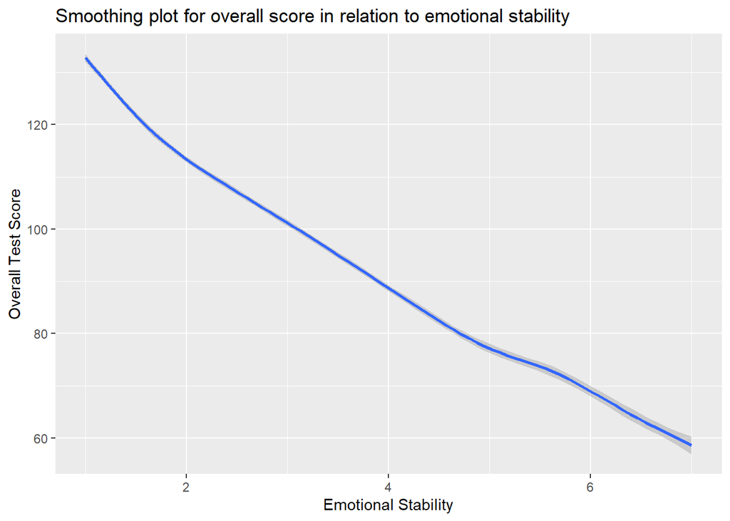

```r
ggplot(data=d)+
  geom_smooth(mapping=aes(emo,score))+
  xlab("Emotional Stability") + ylab("Overall Test Score")+
  ggtitle("Smoothing plot for overall score in relation to emotional stability")
```

# 4. Regression model for overall test score in relation to emotional stability

- *Y* Dependent variable = score
- *X* Independent variable = emotional stability

```r
res.reg <- lm(score~emo,data=d)
summary(res.reg)
```

```
##
## Call:
## lm(formula = score ~ emo, data = d)
##
## Residuals:
##     Min      1Q  Median      3Q     Max
## -85.176 -16.489  -1.832  15.370 109.886
##
## Coefficients:
##             Estimate Std. Error t value Pr(>|t|)
## (Intercept) 139.5197     0.3001   464.9   <2e-16 ***
## emo         -12.3437     0.0843  -146.4   <2e-16 ***
## ---
## Signif. codes:  0 '***' 0.001 '**' 0.01 '*' 0.05 '.' 0.1 ' ' 1
##
## Residual standard error: 23.1 on 32868 degrees of freedom
## Multiple R-squared:  0.3948, Adjusted R-squared:  0.3948
## F-statistic: 2.144e+04 on 1 and 32868 DF,  p-value: < 2.2e-16
```

The goodness of fit index $R^2$ is equal to 0.395. This model showed a Medium-Low level of Quality.

The *p-value* is <2.2e-16. It is significantly less than 5% thus I reject the null hypothesis. Therefore I conclude that the model is statistically significant.